# Zaman Serisi Final

Yasemin Hızarcı 121516005

**Veri setinize ilişkin zaman serisi grafiğini çizdiriniz ve veri setinizi tanıtınız.veri setinizi train ve test olarak ikiye ayırınız.**

### **Veri setinin tanıtılması:**

**Norveç’te Yeni Araba Satışları**

2007-2017 için aylık otomobil satışları hakkında bilgi veren bir veri setidir.

Norveç’teki otomobil satışlarının aylara göre özet istatistiklerini içerir.

**Quantity(Miktar):** Satılan toplam birim sayısı

**Quantity_YoY:** Birim cinsinden YY(bir önceki yılın aynı dönemine kıyasla) degişim

**Import(ithalat):** İthal edilen toplam birim sayısı

**Import_YoY:** Birim cinsinden geçen yıl aynı aya göre degişim.

**Used:** Ülke içindeki birim sahibi değişikliklerinin toplam sayısı (2012 verileri mevcuttur)

**Used_YoY:** Birim cinsinden YY degişim.

**Avg_CO2:** Belirli bir ayda satılan tüm arabaların ortalama CO2 emisyonu (g / km cinsinden)

**Bensin_Co2:** Belirli bir ayda satılan benzin yakıtlı arabaların ortalama CO2 emisyonu (g / km cinsinden)

**Diesel_Co2:** Belirli bir ayda satılan dizel yakıtlı arabaların ortalama CO2 emisyonu (g / km olarak)

**Quantity_Diesel:** Belirli bir ayda ülkede satılan dizel yakıtlı araba sayısı

**Diesel_Share:** Dizel arabaların toplam satışlar içindeki payı (Miktar Dizel / Miktar)

**Diesel_Share_LY:** Bir yıl önceki toplam satışlar içinde dizel arabaların payı

**Quantity_Hybrid:** Ülkede satılan yeni hibrit otomobil sayısı (hem PHEV hem de BV)

**Quantity_Electric:** Ükede satılan yeni elektrikli otomobil sayısı.

**Import_Electric:** Ülkeye ithal edilen kullanılmış elektrikli otomobil sayısı.

```r
library(fpp2)
carsales<-read.csv(file="C:/Users/yasem/OneDrive/Masaüstü/norwaycarsales.csv",
header=TRUE,sep=",")
head(carsales)
```

```
##   Year Month Quantity Quantity_YoY Import Import_YoY Used Used_YoY Avg_CO2
## 1 2007     1    12685         5227   2276        257   NA       NA     152
## 2 2007     2     9793         2448   1992        -89   NA       NA     156
## 3 2007     3    11264         1445   2626         45   NA       NA     159
## 4 2007     4     8854          504   2220       -130   NA       NA     160
## 5 2007     5    12007         1592   2881          7   NA       NA     160
## 6 2007     6    11083         1545   3038         23   NA       NA     161
##   Bensin_Co2 Diesel_Co2 Quantity_Diesel Diesel_Share Diesel_Share_LY
## 1        155        152           10072         79.4            52.5
## 2        159        155            7222         73.7            47.4
## 3        161        158            7965         70.7            48.1
## 4        165        158            6116         69.1            48.4
## 5        163        159            8519         71.0            49.1
## 6        163        160            8290         74.8            49.5
##   Quantity_Hybrid Quantity_Electric Import_Electric
## 1              NA                NA              NA
## 2              NA                NA              NA
## 3              NA                NA              NA
## 4              NA                NA              NA
## 5              NA                NA              NA
## 6              NA                NA              NA
```

**veri, 2007 1. aydan 2017 1. aya kadar devam eden aylık bir veridir.**

```r
summary(carsales)
```

```
##       Year          Month           Quantity      Quantity_YoY
##  Min.   :2007   Min.   : 1.000   Min.   : 5353   Min.   :-4548.0
##  1st Qu.:2009   1st Qu.: 3.000   1st Qu.:10250   1st Qu.: -526.0
##  Median :2012   Median : 6.000   Median :11385   Median :  493.0
##  Mean   :2012   Mean   : 6.455   Mean   :11134   Mean   :  392.6
##  3rd Qu.:2014   3rd Qu.: 9.000   3rd Qu.:12337   3rd Qu.: 1445.0
##  Max.   :2017   Max.   :12.000   Max.   :14207   Max.   : 5227.0
##
##      Import       Import_YoY         Used          Used_YoY
##  Min.   :1048   Min.   :-1810   Min.   :24106   Min.   :-6261.0
##  1st Qu.:1812   1st Qu.: -495   1st Qu.:34212   1st Qu.: -392.0
##  Median :2263   Median : -114   Median :37079   Median :  855.0
##  Mean   :2204   Mean   : -135   Mean   :36865   Mean   :  973.1
##  3rd Qu.:2625   3rd Qu.:  162   3rd Qu.:39797   3rd Qu.: 2708.0
##  Max.   :3768   Max.   : 1334   Max.   :44106   Max.   : 5896.0
##                                 NA's   :60      NA's   :72
##     Avg_CO2        Bensin_Co2      Diesel_Co2    Quantity_Diesel
##  Min.   : 84.0   Min.   : 94.0   Min.   :118.0   Min.   : 3422
##  1st Qu.:110.0   1st Qu.:120.0   1st Qu.:133.0   1st Qu.: 5434
##  Median :132.0   Median :131.0   Median :136.0   Median : 6583
##  Mean   :129.5   Mean   :133.7   Mean   :141.4   Mean   : 6582
##  3rd Qu.:151.0   3rd Qu.:150.0   3rd Qu.:151.0   3rd Qu.: 7808
##  Max.   :162.0   Max.   :165.0   Max.   :166.0   Max.   :10072
##
##   Diesel_Share   Diesel_Share_LY Quantity_Hybrid Quantity_Electric
##  Min.   :26.30   Min.   :38.00   Min.   : 159    Min.   :  43
##  1st Qu.:48.50   1st Qu.:49.40   1st Qu.: 443    1st Qu.: 309
##  Median :68.70   Median :68.70   Median : 899    Median :1260
##  Mean   :60.51   Mean   :62.28   Mean   :1255    Mean   :1154
##  3rd Qu.:73.70   3rd Qu.:74.00   3rd Qu.:1556    3rd Qu.:1906
##  Max.   :81.40   Max.   :81.40   Max.   :4419    Max.   :3391
##                                  NA's   :48      NA's   :48
##  Import_Electric
##  Min.   : 33.0
##  1st Qu.:197.0
##  Median :286.0
##  Mean   :306.9
##  3rd Qu.:433.0
##  Max.   :746.0
##  NA's   :68
```

**Bu çalışmada “Quantity” (Satılan toplam birim sayısını belirten değişken) kullanılacaktır**

### **Zaman Serisi Grafiği**

“Quantity” değişkenini zaman serisi haline getiriyorum.

```r
Quantity <- ts(carsales$Quantity, start = c(2007,1), frequency = 12)
Quantity
```

```
##        Jan   Feb   Mar   Apr   May   Jun   Jul   Aug   Sep   Oct   Nov   Dec
## 2007 12685  9793 11264  8854 12007 11083 12062 10786  9340 11646 10453  9222
## 2008  9901 10567  9506 11704 10217  9670  9605  7833  8453  8390  6952  7819
## 2009  5353  6287  7601  7504  7421  7581  9394  7967  9530 10187  9600 10250
## 2010  9697  9094 11486 10677  9896 11119 11507 10414 11137 10683 11908 10136
## 2011 10372 10543 12901 11330 13005 10354 11189 11464 11737 11543 12357 11550
## 2012 10838 10925 13051 10876 12612 11053 11920 11790 11134 12413 11986  9369
## 2013 11639 11322 10735 13988 12012 10948 11312 11660 12168 12893 12079 11395
## 2014 11385 11246 13861 12115 12337 11441 11690 11444 11585 12963 11486 12649
## 2015 10523 10685 14159 12782 12036 14207 12394 12604 12421 13197 12600 13078
## 2016 10991 12222 13875 14116 12864 13681 11040 13232 13854 11932 13194 13602
## 2017 13055
```

**Quantity değişkeni için zaman serisi grafiği:**

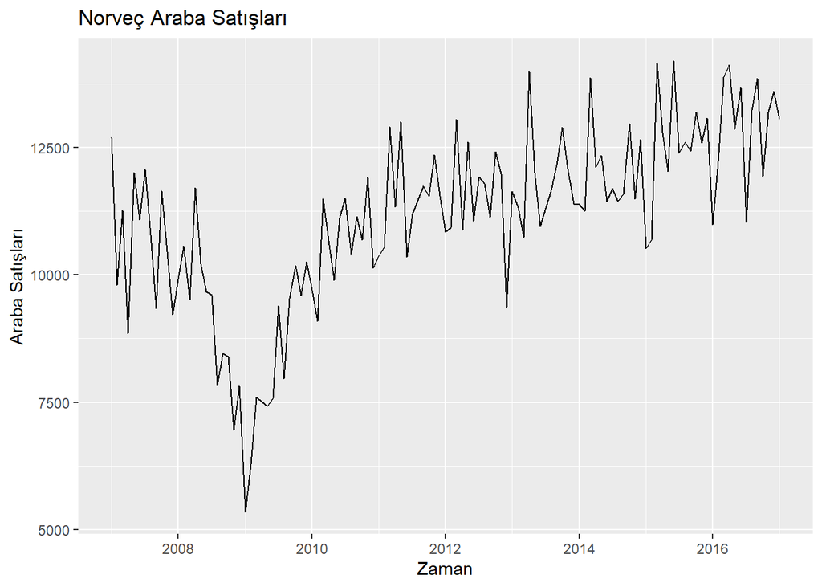

```r
autoplot(Quantity) +
ggtitle("Norveç Araba Satışları ") +
xlab("Zaman") +
ylab("Araba Satışları")
```

Bu grafikten araba satışlarının 2009 a kadar düşüşte olduğu,2009 sonrasında ise artan bir trend gösterdiği görülüyor.Mevsimsellik ile ilgili belirgin bir durum söz konusu değildir.

### Verinin Test ve Train olarak ayrılması:

```r
train<-window(Quantity,end=c(2014,12))#ilk 96 ayı train olarak aldım.
test<-window(Quantity, start=c(2015,1)) #son 25 ayı test seti olarak aldım.
```

# **1. SORU**:

Training setinizi lineer regresyon,lineer spline ve kübik spline regresyon yaklaşımlarını kullanarak modelleyiniz.

```r
library(fpp2)

#lineer regresyon modeli:

fit.lin <- tslm(train ~ trend)

#lineer spline model:

t <- time(train)
t.break1 <- 2009
t.break2 <- 2013
tb1 <- ts(pmax(0, t - t.break1), start = 2007)
tb2 <- ts(pmax(0, t - t.break2), start = 2007)

fit.pw <- tslm(train ~ t + tb1 + tb2)


#cubic spline model:

fit.spline <- tslm(train ~ t + I(t^2) + I(t^3)+
  I(tb1^3) + I(tb2^3))
```

## a)

**Modelleri AICc kriterine göre kıyaslayıp daha uygun olduğunu düşündüğünüz modeli belirleyiniz.**

```r
CV(fit.lin)
```

```
##           CV          AIC         AICc          BIC        AdjR2
## 1.999707e+06 1.394537e+03 1.394798e+03 1.402230e+03 2.860007e-01
```

```r
CV(fit.pw)
```

```
##           CV          AIC         AICc          BIC        AdjR2
## 1.260385e+06 1.349712e+03 1.350378e+03 1.362533e+03 5.613120e-01
```

```r
CV(fit.spline)
```

```
##           CV          AIC         AICc          BIC        AdjR2
## 1.339027e+06 1.356637e+03 1.357581e+03 1.372023e+03 5.331431e-01
```

**AICc en küçük olan model en iyisidir.Buradan lineer spline modelin en iyisi olduğu görülmektedir.**

## b)

**Uygun bulduğunuz modeli kullanarak test setini tahmin ediniz ve tahminlere ilişkin RMSE değerini hesaplayınız**

```r
t.new <- t[length(t)] + seq(25)/12   # trainden sonraki 25 ay için
tb1.new <- tb1[length(tb1)] + seq(25)/12
tb2.new <- tb2[length(tb2)] + seq(25)/12

newdata <- cbind(t=t.new, tb1=tb1.new, tb2=tb2.new) %>%
  as.data.frame()

fcasts.pw <- forecast(fit.pw, newdata = newdata)   #lineer spline modeli ile trainden sonraki 25 ay tahmin ediliyor.

accuracy(fcasts.pw,test)
```

```
##                    ME     RMSE       MAE       MPE      MAPE      MASE
## Training set    0.000 1072.411  846.6752 -1.279307  8.484421 0.5709068
## Test set     1263.182 1692.201 1510.1630  9.217428 11.526847 1.0182918
##                    ACF1 Theil's U
## Training set 0.21183518        NA
## Test set     0.06065551  1.124762
```

**RMSE** değeri **1692** bulunmuştur.

## c)

**Uygun bulduğunuz modelin hem training hem de test seti üzerindeki uyumunu gösteren zaman serisi grafiğini çizdiriniz.**

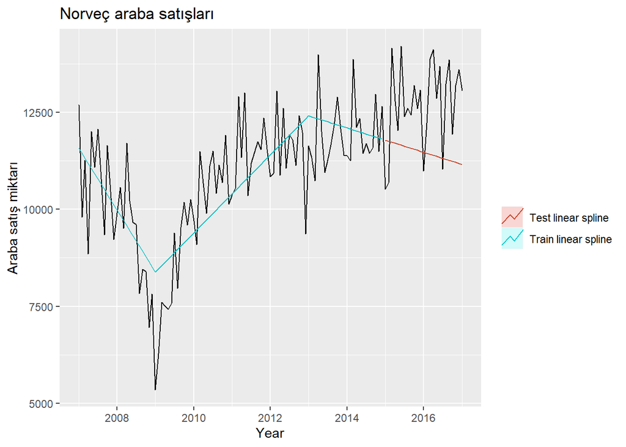

```r
autoplot(Quantity)+
  autolayer(fitted(fit.pw), series = "Train linear spline")+  #train seti için trend
  autolayer(fcasts.pw, series="Test linear spline",PI=FALSE)+  #test seti için trend
  xlab("Year") + ylab("Araba satış miktarı") +ggtitle("Norveç araba satışları") +
  guides(colour = guide_legend(title = " "))
```

Model train seti üzerinde 2009 yılı için yeterince iyi değildir.2009 yılında gerçekte araba satışları daha düşüktür.

Modelin test seti üzerindeki tahmini iyi değildir.Gerçekte test setinde araba satışları artan bir trend gösterirken modelin tahmininde azalan bir trend çizgisi tahmin edilmiştir.

## d)

**Hatalara ilişkin varsayımları kontrol ediniz.**

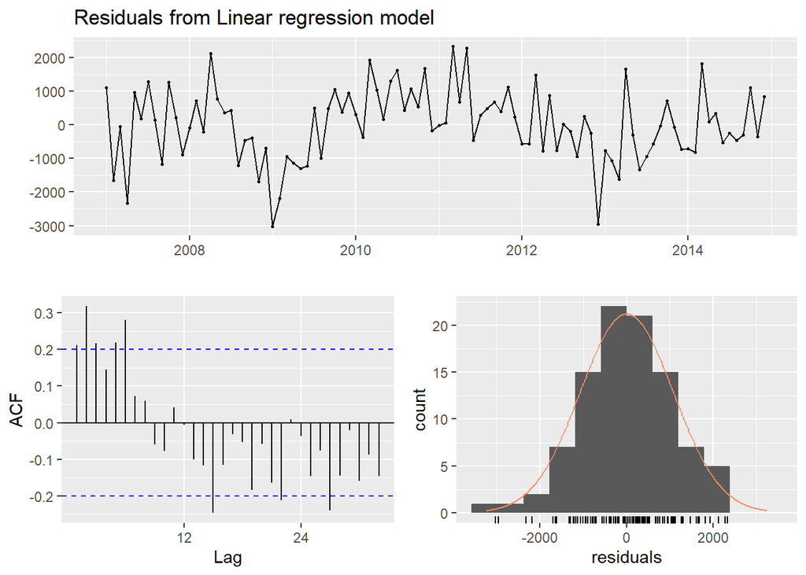

```
##
##  Breusch-Godfrey test for serial correlation of order up to 19
##
## data:  Residuals from Linear regression model
## LM test = 29.49, df = 19, p-value = 0.05865
```

```r
checkresiduals(fit.pw)
```

İlk grafikte artıkların 0 etrafında dağılımının biraz düzensiz olduğu görülüyor.

Histogramdan dağılımın normal dağılıma yakın olduğu görülüyor.

# **2. SORU**

## a)

**Uygun hareketli ortalama(moving average) yöntemini seçip verinizin trend bileşenini belirleyiniz ve orijinal veri üzerinde grafikleyiniz.**

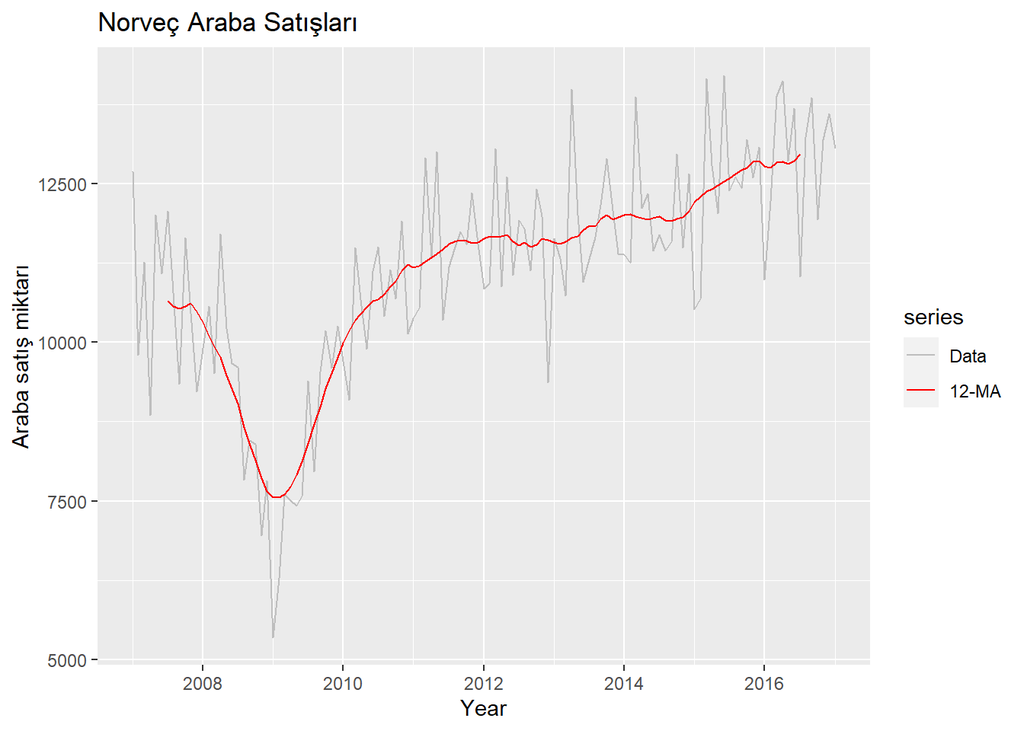

```r
autoplot(Quantity, series="Data") +
autolayer(ma(Quantity, 12), series="12-MA") +
xlab("Year") + ylab("Araba satış miktarı") +
ggtitle("Norveç Araba Satışları") +
scale_colour_manual(values=c("Data"="grey","12-MA"="red"),
breaks=c("Data","12-MA"))
```

ma değeri aylık veriye uygun olarak alınmıştır.

Gri çizgiler orijinal zaman serisidir.Kırmızı çizgiler ise hareketli ortalama yöntemiyle elde edilmiş trend çizgisidir.

Kırmızı trend çizgisi ve orijinal veri incelendiğinde trend çizgisinin verinin trendini iyi bir şekilde gösterdiği görülüyor.

## b)

**Uygun STL ayrıştırması ile verinizi ayrıştırıp grafikleyiniz.**

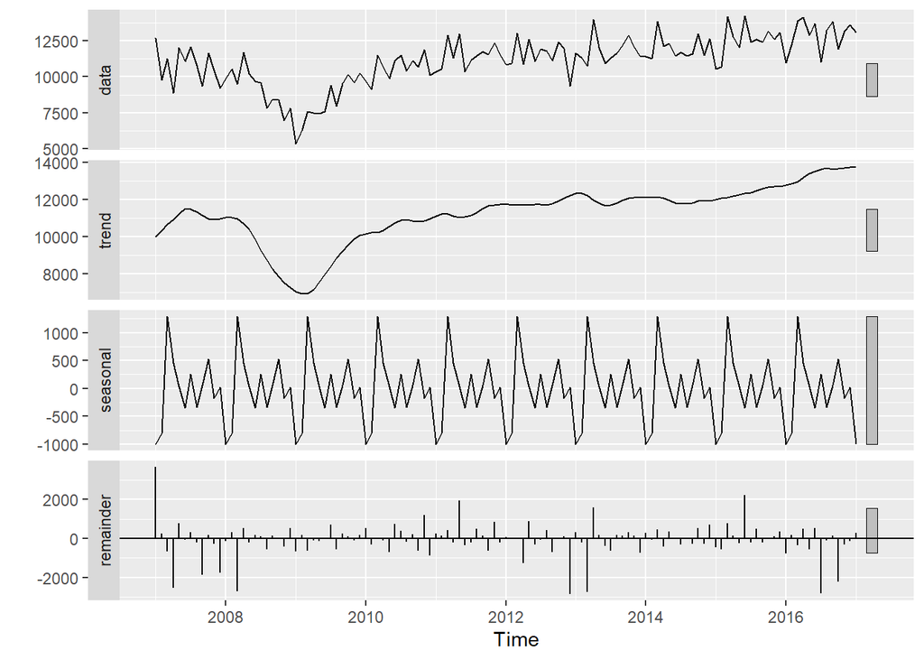

```r
Quantity %>%
stl(t.window=9, s.window="periodic", robust=TRUE) %>%
autoplot()
```

t.window, trend bileşeni tahmin edilirken kullanılacak ardışık gözlemlerin sayısıdır ve 9 olarak alınmıştır.Mevsimsel bileşen ise periyodik(mevsimler boyu aynı olacak şekilde) alınmıştır.

En üstte verinin zaman serisi grafiği mevcuttur.Trend grafiği ise bu zaman serisinin trendini uygun şekilde çizmiştir.

Alt panelde gösterilen geri kalan bileşen, mevsimsel ve trend döngüsü bileşenleri veriden çıkarıldığında geriye kalan kısımdır.

## c)

**Verinizdeki trend ve mevsimsellik bileşenlerinin gücünü belirleyiniz.**

### Trend:

Güçlü bir trend gösteren veriler için, mevsimsellikten arındırılmış veriler, reminder bileşenden çok daha fazla varyasyona sahip olmalıdır. Bu nedenle Var((Rt))/Var((Tt + Rt)) nispeten küçük olmalıdır.

```r
a=Quantity %>%stl(t.window=9, s.window="periodic", robust=TRUE)

seasonal <- a[["time.series"]][,1]
trend<-a[["time.series"]][,2]
remainder<-a[["time.series"]][,3]
```

```r
max(0,1-(var(remainder)/(var(trend+remainder))))
```

```
## [1] 0.7392764
```

```r
var(remainder)/(var(trend+remainder))
```

```
## [1] 0.2607236
```

var(RT)/var(Tt+Rt) küçüktür.Bu da veride trendin güçlü olduğunu gösterir.

### Mevsimsellik

0’a yakın FS değerine sahip bir seri neredeyse hiç mevsimsellik göstermezken, güçlü mevsimselliğe sahip bir seride 1’e yakın FS değeri olacaktır.Çünkü Var(Rt), Var(St + Rt)’den çok daha küçük olacaktır.

```r
FS=max(0,1-(var(remainder)/(var(seasonal+remainder))))
FS
```

```
## [1] 0.1230171
```

FS değeri küçük olduğu için veride mevsimselliğin güçlü olmadığı sonucuna varılır.

## d)

**Training set üzerinde STL ayrıştırmasını kullanarak, test setinizi tahmin ediniz.Orijinal veri üzerine tahminlerinizi grafikleyip tahminlere ilişkin RMSE değerini hesaplayınız.**

```r
# STL ayrıştırması:

fit <- stl(train, t.window=9, s.window="periodic",
robust=TRUE)


# Test setinin tahmin edilmesi:

fcasts=forecast(fit,h=25)
```

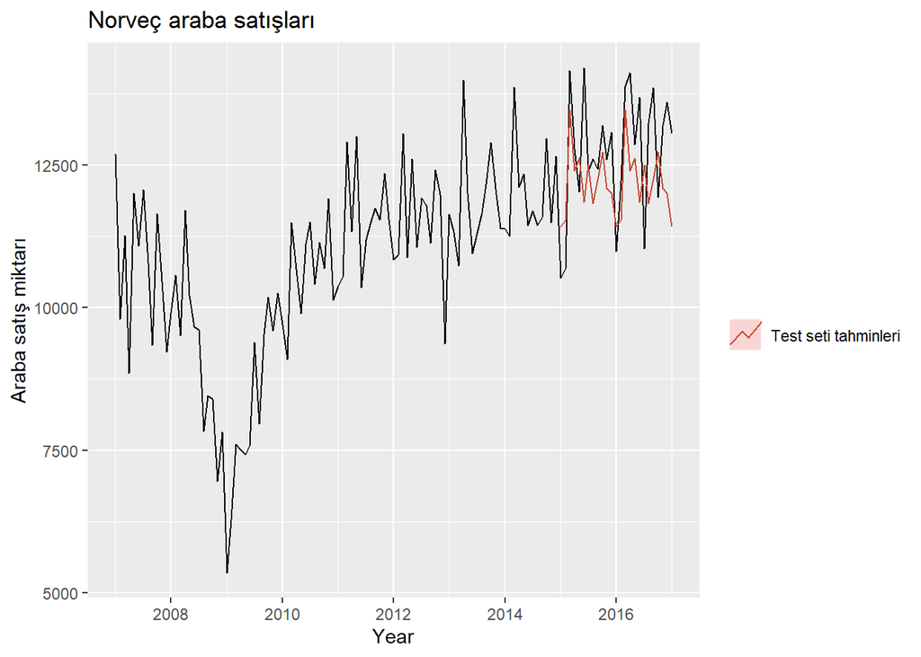

```r
autoplot(Quantity)+
  autolayer(fcasts, series="Test seti tahminleri",PI=FALSE)+xlab("Year") +
  ylab("Araba satış miktarı") +ggtitle("Norveç araba satışları") +
  guides(colour = guide_legend(title = " "))
```

Kırmızı renkli çizgiler orijinal veri üzerine çizdirilmiş test seti tahminleridir.Sonlara doğru tahmin gücünün azaldığı görülmektedir.

```r
accuracy(fcasts,test)
```

```
##                     ME     RMSE      MAE        MPE     MAPE      MASE
## Training set  20.74862 1004.580 779.3892 -0.5835326 7.667651 0.5255364
## Test set     541.96441 1118.115 950.9306  3.7093109 7.381580 0.6412055
##                    ACF1 Theil's U
## Training set -0.1434806        NA
## Test set     -0.2875807 0.7334141
```

Tahminlere ilişkin **RMSE** değeri **1118.115** tir.